# “What did the presidents asy at their inauguation?”

Here I explore the texts of U.S.presidents’inaugrual speeches, from that of George Washington to that of Donald Trump which was delivered on 20th Jan. I use tools from text mining and natural language processing like sentiment analysis and topic modeling to analyze interesting trends and patterns.

First, I will create the wordclouds for both overall speech and individual speeches

# word cloud for overall speech

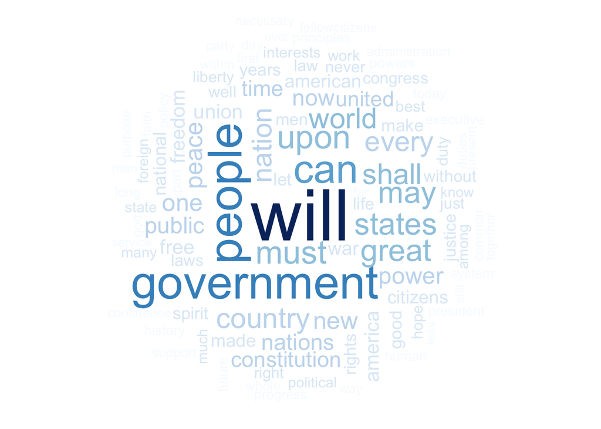

I noticed most of the speeches mentioned ‘will’, ‘government’ and ‘people’. I guess they all expected to strengthen the relationship between government and people. What about the focus of each individual speech?

# Interactive visualize important words in individual speeches

Next, I use sentences as units of analysis for this project since sentences are natural languge units for organizing thoughts and ideas. For each extracted sentence, I apply sentiment analysis by using NRC sentiment lexion. I use a sequential id for every sentence called ‘sent.id’ and calulated the number of words in each sentence called ‘sentence length’.

After generating each sentences for all speeches, I expect to focus on analyzing the length of sentences. I chose a sebset of better known presidents or presidential candidates to analysis for simple visualization.

```r
# Select several speech to compare

sel.comparison=c("DonaldJTrump","JohnMcCain", "GeorgeBush", "MittRomney", "GeorgeWBush", "RonaldReagan","AlbertGore,Jr","HillaryClinton","JohnFKerry", "WilliamJClinton","HarrySTruman", "BarackObama", "LyndonBJohnson","GeraldRFord", "JimmyCarter", "DwightDEisenhower", "FranklinDRoosevelt","HerbertHoover","JohnFKennedy","RichardNixon","WoodrowWilson","AbrahamLincoln", "TheodoreRoosevelt", "JamesGarfield","JohnQuincyAdams", "UlyssesSGrant", "ThomasJefferson", "GeorgeWashington", "WilliamHowardTaft", "AndrewJackson","WilliamHenryHarrison", "JohnAdams")
```

# Word numbers of sentences for each selectd speech

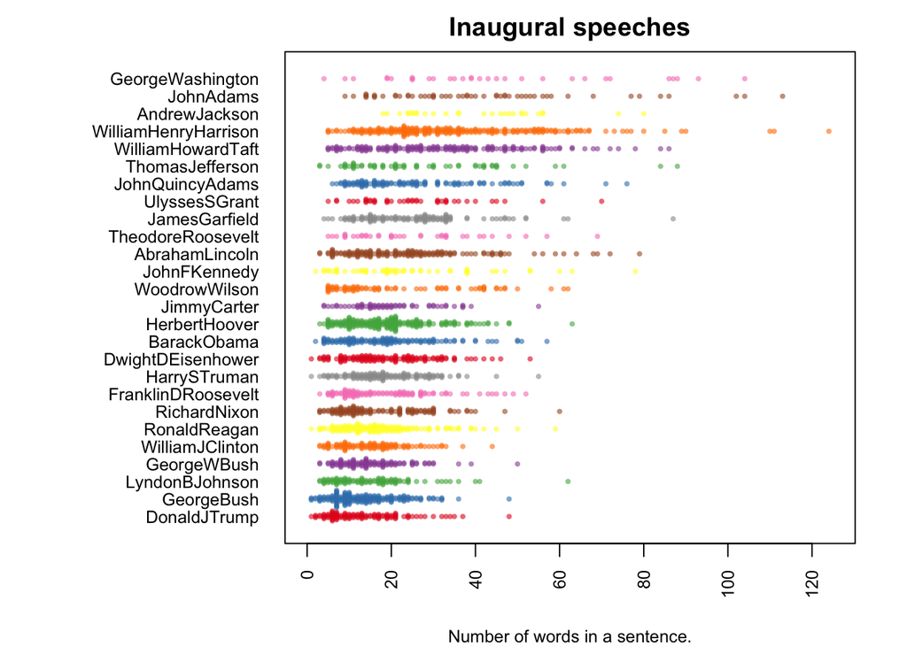

Compared with prior prior U.S. presidents such as George Washington, I noticed that several presidents especially for Donoald Trump prefered very short sentences in their speech. As time goes on, most of the presidents prefer short sentences, which probabely seem more free-style speeches. I guess Trump expected to talk very little but do a lot in the future.

So, What are these short sentences in Trump and Obama speeches? Let’s compare the differences.

```
##            sentences
## 1         Thank you.
## 2                 C.
## 3         Thank you.
## 4     God bless you.
## 5         Thank you.
## 6 God bless America.
```

```
##                 sentences
## 1              Thank you.
## 2              Thank you.
## 3 diversity and openness;
## 4              Thank you.
```

I noticed Lots of unformal sentences used in his speech such as ‘Thank you’ and ‘God bless America’, which probabely proved they weren’t good at delivering a formal speech.

What about the emotions in all speeches? How the presidents shift sentiments in their speeches? Now, I will cluster the emtions in all speeches

# Clustering of emotions

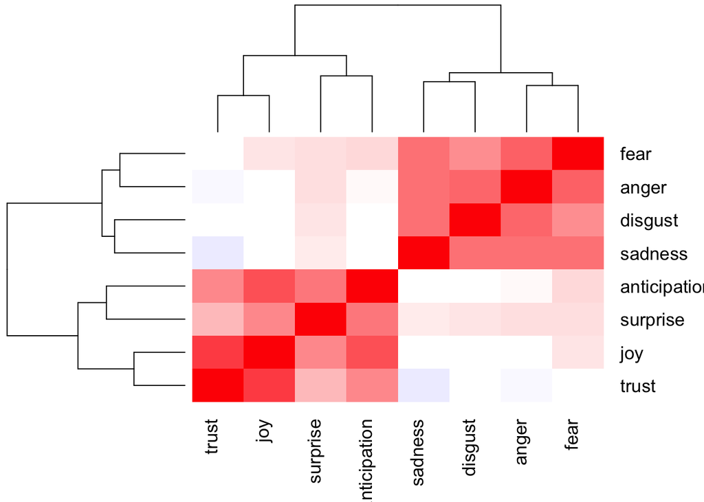

Looking through all speeches, I can cluster emotions into two main groups. Group1 (negative): anger, fear, sadness, disgust Group2 (positive): trust, surprise, joy, anticipation These two groups represents very differrent emotions.

# Bar plot for mean value of clustering emotions for sentence list

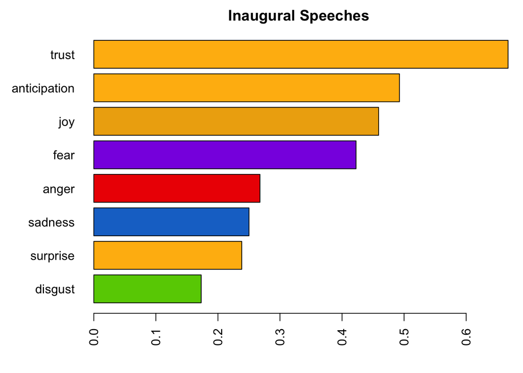

Let’s look at Trump and Obama in detail. What are the emotionally charged sentencesin their speeches? # Sentences with emotions for Trump and Obama

```
## [1] "Donald Trump"
```

```
## [1] "There should be no fear."
## [2] "And God bless America."
## [3] "America will start winning again, winning like never before."
## [4] "And God bless America."
## [5] "And God bless America."
## [6] "America will start winning again, winning like never before."
## [7] "They have been magnificent."
## [8] "And God bless America."
```

```
## [1] "Barack Obama"
```

```
## [1] "The Capital was abandoned."
## [2] "This is the journey we continue today."
## [3] "Our capacity remains undiminished."
## [4] "Our capacity remains undiminished."
## [5] "when the wages of honest labor liberate families from the brink of hardship."
## [6] "The Capital was abandoned."
## [7] "when the wages of honest labor liberate families from the brink of hardship."
## [8] "We affirm the promise of our democracy."
```

What about the clustering emotions relationship amoung all speeches? In this project, I expect to cluster them into five groups. That means presidents in the same group used similar emotions in their speeches.

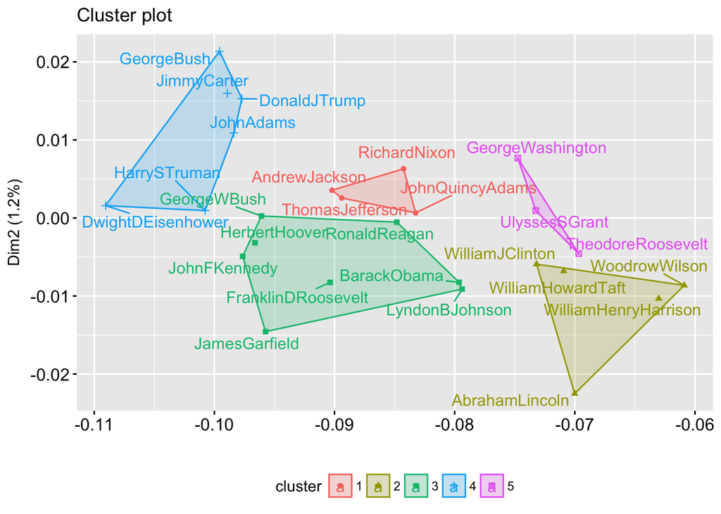

I see that DonoldJTrump, GeorgeBush, JimmyCarter and JohnAdams are analyzed in the same cluster. Although they used different length of sentences in their speeches, I was surprised that they delivered similar emotions. Thus, there are no necessary relationships between the length of sentences and the emotion of speeches.

Finally, I expect to dig more stories on the topic of speeches. # Data analysis – Topic modeling

# Create 10 topics for all speeches

```
##
##   1   2   3   4   5   6   7   8   9  10
## 536 655 495 455 421 518 742 641 452 637
```

```
##       [,1]        [,2]       [,3]         [,4]        [,5]
##  [1,] "happi"     "result"   "difficulti" "sourc"     "attain"
##  [2,] "necessari" "industri" "revenu"     "busi"      "commerc"
##  [3,] "offic"     "confid"   "discharg"   "abil"      "offici"
##  [4,] "anoth"     "singl"    "destroy"    "prejudic"  "insist"
##  [5,] "intern"    "treati"   "prepar"     "contribut" "sincer"
##  [6,] "law"       "legisl"   "enforc"     "amend"     "due"
##  [7,] "work"      "courag"   "build"      "back"      "conscienc"
##  [8,] "dream"     "came"     "celebr"     "thank"     "triumph"
##  [9,] "union"     "object"   "feder"      "grant"     "none"
## [10,] "democraci" "mankind"  "small"      "weak"      "digniti"
##       [,6]        [,7]
##  [1,] "disturb"   "various"
##  [2,] "economi"   "trade"
##  [3,] "heretofor" "profound"
##  [4,] "prefer"    "southern"
##  [5,] "cultiv"    "aggress"
##  [6,] "remedi"    "immedi"
##  [7,] "young"     "bold"
##  [8,] "vice"      "gather"
##  [9,] "reserv"    "perpetu"
## [10,] "choic"     "join"
```

```
##       Topic 1    Topic 2     Topic 3   Topic 4     Topic 5    Topic 6
##  [1,] "countri"  "public"    "will"    "can"       "nation"   "law"
##  [2,] "great"    "secur"     "shall"   "one"       "peac"     "upon"
##  [3,] "spirit"   "necessari" "duti"    "citizen"   "war"      "parti"
##  [4,] "mani"     "industri"  "peopl"   "peopl"     "great"    "congress"
##  [5,] "much"     "revenu"    "may"     "everi"     "justic"   "execut"
##  [6,] "prosper"  "product"   "offic"   "good"      "polici"   "question"
##  [7,] "everi"    "busi"      "confid"  "must"      "foreign"  "constitut"
##  [8,] "present"  "use"       "faith"   "equal"     "interest" "made"
##  [9,] "institut" "commerc"   "support" "polit"     "never"    "subject"
## [10,] "danger"   "increas"   "servic"  "civil"     "countri"  "legisl"
## [11,] "happi"    "without"   "upon"    "right"     "relat"    "effect"
## [12,] "liberti"  "demand"    "purpos"  "well"      "just"     "opinion"
## [13,] "exist"    "forc"      "countri" "individu"  "secur"    "elect"
## [14,] "experi"   "requir"    "public"  "common"    "maintain" "principl"
```

[output cut: 27 more lines]

In summary, presidents all used relatively different topics and emotions. However, they all expect to try their best to strengthen the power of Americ in the world. Although, what happens in the future is uncertain, I suppose American should support Trump now so that they can achieve their dreams.